# Dictionary Methods

Introduction to Text as Data

Amber Boydstun & Cory Struthers

January 25-27, 2024

### Introduction

Dictionary approaches require the researcher to choose a set of words that captures a concept. Oftentimes the concept is `sentiment’, or the degree to which the language is positive vs. negative.

Other times, we’re more interested in measuring the prevalence of a topic in a text, such as economic policy, giraffes, or populism.

If the concept we want to measure can be reasonably captured with a list of words, then dictionary methods may be a good approach. The method is relatively straightforward: For each concept we want to measure, we come up with a list of words (also known as a “dictionary” or “lexicon”) and then we measure the prevalence of those words in the corpus.

In this module, we need the following packages:

````r
```{r, setup, include=FALSE}
````

[output not shown]

```r
getwd() # view working directory
```

```
[1] "/Users/cstruth/Dropbox/text-as-data-JUST-CORY-AND-AMBER/modules_2024/MODIFIED_4_Dictionaries/github/intro-tad-dict-2024/docs"
```

### Apply sentiment analysis

```r
# Convert it to document-feature matrix format
rest_dfm = reviews %>%
    tokens(remove_punct = TRUE) %>% ## remove punctuation
    dfm(tolower = TRUE)  %>% ##  lowercase
    dfm_remove(pattern = stopwords("english")) ## ignore common words on a "stop" list
rest_dfm
```

```
Document-feature matrix of: 5 documents, 11 features (72.73% sparse) and 0 docvars.
      features
docs   great menu loved definitely come food like service alright recommend
  rev1     1    1     1          1    1    0    0       0       0         0
  rev2     1    0     0          0    0    1    1       1       0         0
  rev3     0    0     0          0    0    1    0       0       1         0
  rev4     0    0     0          0    0    0    0       1       0         1
  rev5     0    0     0          0    0    0    0       0       0         0
[ reached max_nfeat ... 1 more feature ]
```

Is the dictionary characterizing the reviews well?

By adding compound and negation terms to the dictionary, we better represent the sentiment in the reviews. Importantly, when we add a negation term (e.g., “not good”), `dfm_lookup` no longer counts the positive word (“good”) in the text because it matches to the compound found in the dfm.

```r
rest_dfm_out
```

```
Document-feature matrix of: 5 documents, 2 features (50.00% sparse) and 0 docvars.
      features
docs   positive negative
  rev1        2        0
  rev2        2        0
  rev3        0        0
  rev4        1        1
  rev5        0        1
```

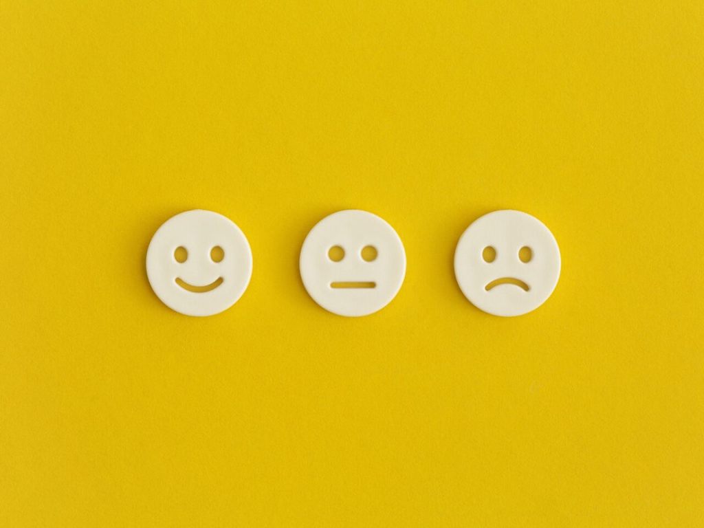

An alternative approach to creating your own dictionary is using an established one. The use of established dictionaries is common in sentiment analysis.

For example, [*Lexicoder Sentiment Dictionary (2015)*](https://quanteda.io/reference/data_dictionary_LSD2015.html) (LSD) is a built-in dictionary in `quanteda` package (there are others!). This dictionary consists of 2,858 “negative” and 1,709 “positive” sentiment words. Negations of negative and positive words (like our example above illustrates) are also included.

```r
rest_dfm_revised_out
```

```
Document-feature matrix of: 5 documents, 2 features (50.00% sparse) and 0 docvars.
      features
docs   positive negative
  rev1        2        0
  rev2        1        1
  rev3        0        0
  rev4        0        2
  rev5        0        1
```

The [`quanteda.sentiment package`](https://github.com/quanteda/quanteda.sentiment), which we loaded earlier, extends the `quanteda` package with functions for computing sentiment.